# IS451B Lab 1: Solution Manual

TA: Zhijin Zhou

4/12/2018

## Outline:

1. Take-Home practice review: Takyo Software Data
2. In class practice: Predictioning TV Sales

## Take-Home practice: Takyo Software Data

### Data Description

Takyo software catalog firm that sells games and educational software. It started out as a software manufacturer and then added third-party titles to its offerings. It recently revised its collection of items in a new catalog, which it mailed out to its customers. The file `Tayko.csv` contains information on 2000 purchase.

| Freq | last_update_days_ago | Web.order | Gender.male | Address_is_res | US | Spending |
| --- | --- | --- | --- | --- | --- | --- |
| 2 | 3662 | 1 | 0 | 1 | 1 | 128 |
| 0 | 2900 | 1 | 1 | 0 | 1 | 0 |
| 2 | 3883 | 0 | 0 | 0 | 1 | 127 |
| 1 | 829 | 0 | 1 | 0 | 1 | 0 |
| 1 | 869 | 0 | 0 | 0 | 1 | 0 |
| 1 | 1995 | 0 | 0 | 1 | 1 | 0 |

Based on these data and variables, Takyo wants to devise a model for predicting the spending amount that a purchasing customer will yield.

### Questions 1: Create two scatterplots and explore the relationship between

- `Spending` vs. `Freq`
- `Spending` vs. `last_update_days_ago`

#### Read and select data

```r
#read data
tayko.df <- read.csv("Tayko.csv")
```

#### Drawing scatter plots

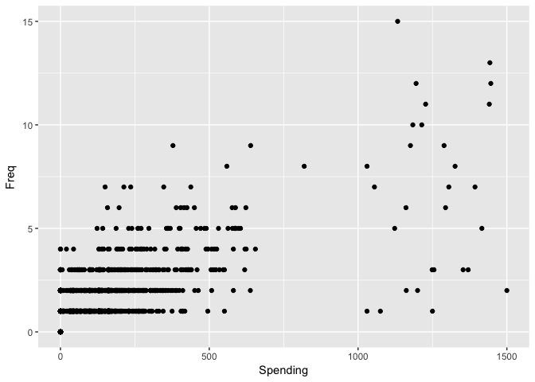

```r
#load packages
library(ggplot2)
# make scatter plots
ggplot(data = tayko.df) +
  geom_point(aes(x = Spending, y = Freq))
```

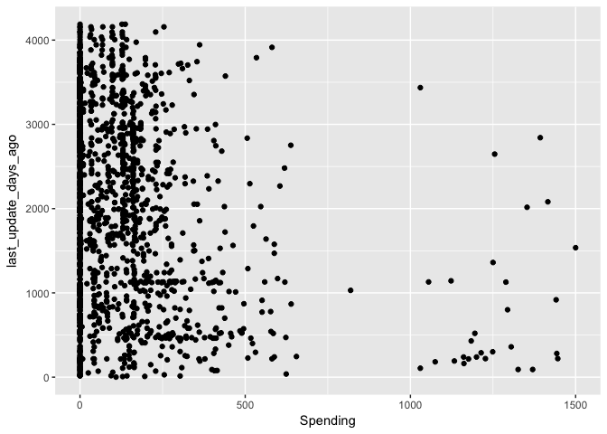

```r
ggplot(data = tayko.df) +
  geom_point(aes(x = Spending, y = last_update_days_ago))
```

Does there seem to be a linear relationship?

### Question 2. Fit a multiple linear regression for Spending

#### Step 1: Partition the 2000 records into `70%` training vs. `30%` validationwith the seed set to 1.

```r
# select variables for regression
selected.var <- c(2, 18, 20, 21, 22,23,24,25)
```

To create a train and validation set, we are going to split randomly this data set into 70% train and 30% test.

```r
set.seed(1)  # set seed for reproducing the partition
# Random sample indexes
train.index <- sample(c(1:2000), 2000*0.7)

# Build training and validation set by indexing
train.df <- tayko.df[train.index, selected.var]
valid.df <- tayko.df[-train.index, selected.var]
```

#### Step 2: Multiple linear regression

Basic formula:

$$\begin{equation}
Y = \beta_0 + \beta_1x_1 +\beta_2x_2 + \beta_2x_2 + \dots + \beta_px_p + \epsilon
\end{equation}$$

Run a multiple linear regression for `Spending` vs. `all six predictors` using `lm` function.

Write down the fitted predictive equation.

```r
# use lm() to run a linear regression of Spending on all 6 predictors in the training set
tayko.lm <- lm(Spending~., data = train.df)
```

Display the results

```r
#  use options() to ensure numbers are not displayed in scientific notation.
options(scipen = 999)
summary(tayko.lm)
```

[output not shown]

#### Step 3: Evaluate the predictive accuracy of the model by examining its performance on the validation set.

- We need to use library `forecast`.
- Use `predict` function to make predictions on a new set
- Use `accuracy` to compute common accuracy measures.

Load library

```r
library(forecast)
```

make predictions

```r
# use predict() to make predictions on a new set.
tayko.lm.pred <- predict(tayko.lm, valid.df)

#  use options() to ensure numbers are not displayed in scientific notation.
options(scipen=999, digits = 3)

# use accuracy() to compute common accuracy measures.
accuracy(tayko.lm.pred, valid.df$Spending)
```

[output not shown]

#### Step 4: Create a histogram of the residuals in validation set.

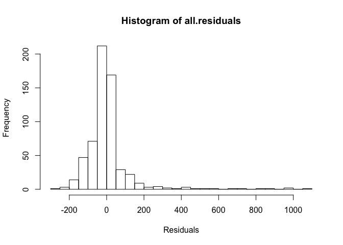

```r
#  use options() to ensure numbers are not displayed in scientific notation.
options(scipen=999, digits = 0)

all.residuals <- valid.df$Spending - tayko.lm.pred
hist(all.residuals, breaks = 25, xlab = "Residuals")
```

## In class practice: Predictioning TV Sales

### Data Description

This practice leverages a simple data set that contains, in thousands of dollars, `TV`, `Radio`, and `Newspaper` budgets for 200 different markets along with the Sales, in thousands of units, for each market. We will try to use the advertising budgets for each market to predict the sales.

Import the data from `Advertising.csv`.

```r
ad.df <- read.csv("Advertising.csv")
```

- `TV` and `sales`
- `radio` and `sales`
- `newspaper` and `sales`

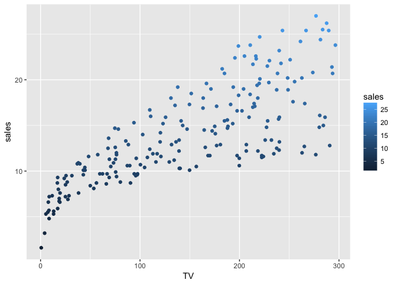

```r
ggplot(data = ad.df) +
geom_point(aes(x = TV, y = sales, color = sales))
```

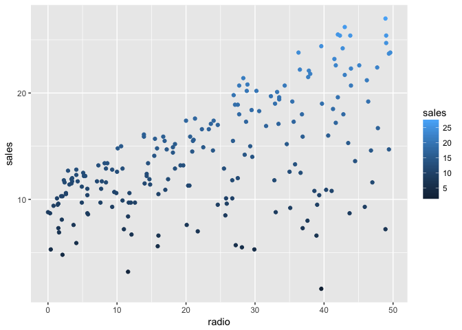

```r
ggplot(data = ad.df) +
geom_point(aes(x = radio, y = sales, color = sales))
```

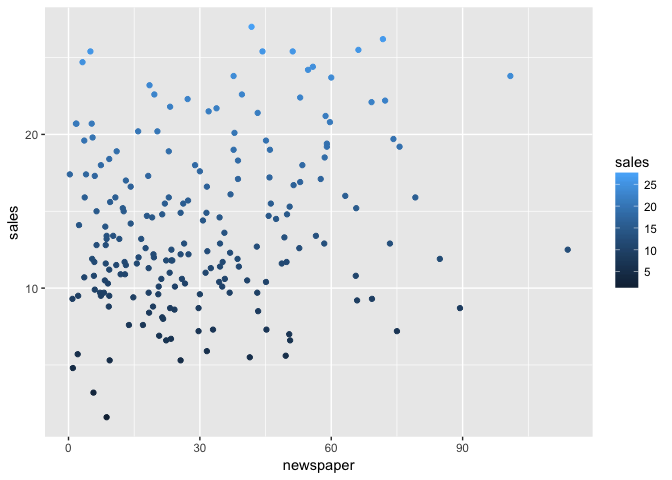

```r
ggplot(data = ad.df) +
geom_point(aes(x = newspaper, y = sales, color = sales))
```

### Question 2

- Partition the data into 80% training vs. 20% validation with the seed set to 123
- Build and estimate a multiple linear regression using `TV`, `Radio`, and `Newspaper` to predict `Sales`.
- Examine and interpret the coefficients. What do you find?

```r
#partition dataset

set.seed(123)  # set seed for reproducing the partition
train.index <- sample(c(1:200), 200*0.8)
train.df <- ad.df[train.index, ]
valid.df <- ad.df[-train.index, ]

#build and estimte model
ad.lm <- lm(sales ~ ., data = train.df)
#  use options() to ensure numbers are not displayed in scientific notation.
options(scipen = 999)
summary(ad.lm)
```

```
##
## Call:
## lm(formula = sales ~ ., data = train.df)
##
## Residuals:
##    Min     1Q Median     3Q    Max
## -5.486 -0.934  0.192  1.191  2.747
##
## Coefficients:
##             Estimate Std. Error t value            Pr(>|t|)
## (Intercept)  3.15198    0.32930    9.57 <0.0000000000000002 ***
## TV           0.04466    0.00150   29.68 <0.0000000000000002 ***
## radio        0.19383    0.00908   21.34 <0.0000000000000002 ***
## newspaper   -0.00444    0.00607   -0.73                0.47
## ---
## Signif. codes:  0 '***' 0 '**' 0 '*' 0 '.' 0 ' ' 1
##
## Residual standard error: 2 on 156 degrees of freedom
## Multiple R-squared:  0.906,  Adjusted R-squared:  0.904
## F-statistic:  502 on 3 and 156 DF,  p-value: <0.0000000000000002
```

### Question 3

- Evaluate the predictive accuracy on the `training set`
- Evaluate the predictive accuracy on the `validation set`
- Compare the results with the predictive accuracy on validation set. Which one seems more accurate? Can you give an explanation?

```r
library(forecast)
# evaluate the performance on the training set
accuracy(ad.lm$fitted.values, train.df$sales)
```

```
##          ME RMSE MAE MPE MAPE
## Test set  0    2   1  -1   11
```

```r
# evaluate the performance on the validation set
ad.lm.pred <- predict(ad.lm, valid.df)
options(scipen=999, digits = 0)
accuracy(ad.lm.pred, valid.df$sales)
```

```
##          ME RMSE MAE MPE MAPE
## Test set -0    2   1 -17   25
```

### Question 4

Create a boxplot of the residuals in validation set

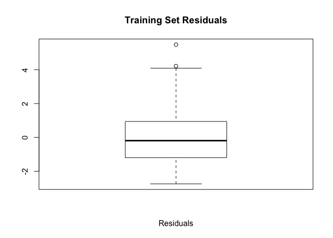

```r
# get the residuals
tr.residuals <- ad.lm$fitted.values - train.df$sales
val.residuals <- valid.df$sales - ad.lm.pred

#plot

boxplot(tr.residuals, xlab = "Residuals", main = "Training Set Residuals")
```

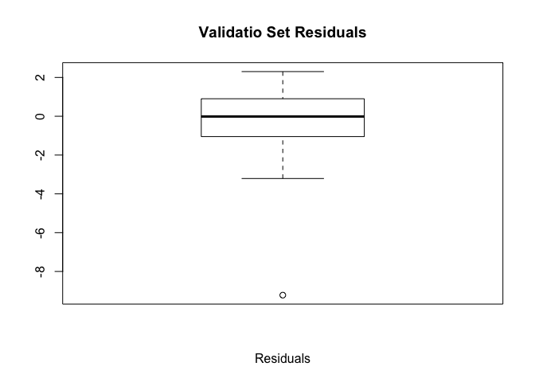

```r
boxplot(val.residuals, xlab = "Residuals", main = "Validatio Set Residuals")
```